# Two Variables: Qualitative

Author

Mica G. Rabusa

Published

November 15, 2026

# The Data

```r
# load packages
library(tidyverse)
library(knitr)
library(gtsummary)
library(ggstatsplot)
library(downlit)
library(broom)
library(here)

# load the data
df <- read_csv(here("Data", "my_dataset.csv"))

df <- df |>
  mutate(
    `Mode` = factor(
     `Mode of Transportation`,
      levels = c("Walking", "Public Commute", "Private Vehicle (Owned car/motorcycle)"),
      ordered = TRUE
    )
  ) |>
  select(
    sufficiency = `Allowance Sufficiency Level`,
    Mode = `Mode of Transportation`,
  )
```

## Transportation and Allowance Sufficiency Data Set

The data was collected from a student survey examining mode of transportation and self-reported allowance sufficiency levels.

A data frame with 68 observations on 2 categorical variables.

- `sufficiency` Sufficient, Enough, Insufficient.
- `Mode` Walking, Public Commute, Private Vehicle.

The first 6 rows of the data set are shown in Table 1.

```r
df |>
  head() |> # getting the first six rows of the data
  kable(col.names = c("Allowance Sufficiency Level", "Mode of Transportation")) # creating a table
```

Table 1: The first 6 observations of the data set.

| Allowance Sufficiency Level | Mode of Transportation |
| --- | --- |
| Enough (Just exactly covers daily requirements) | Walking |
| Enough (Just exactly covers daily requirements) | Walking |
| Enough (Just exactly covers daily requirements) | Public Commute |
| Sufficient (More than enough for basic needs and extras) | Walking |
| Sufficient (More than enough for basic needs and extras) | Walking |
| Enough (Just exactly covers daily requirements) | Walking |

## Descriptive Statistics

The frequency distribution of `sufficiency`(Allowance Sufficiency Level) when grouped according to `Mode`(Mode of Transportation) is shown in Table 2. Most of the respondents rely on Public Commute as their primary mode of transportation, accounting for 35 (51%) of the 68 total respondents, followed by Walking with 18 (26%) and Private Vehicle with 15 (22%). Across allowance sufficiency levels, the largest group of respondents reported having enough allowance (37 respondents), with nearly half of them using public commute (17 respondents, 46%).

```r
df |>
  tbl_cross(
    row = Mode,
    col = sufficiency,
    label = list(
      Mode ~ "Mode of Transportation",
      sufficiency ~ "Allowance Sufficiency Level"
    ),
    percent = "column",
    margin = c("row", "column")
  )
```

Table 2: Summary statistics of `sufficiency` when grouped according to `Mode`.

|  | Allowance Sufficiency Level Enough (Just exactly covers daily requirements) | Allowance Sufficiency Level Insufficient (Not enough to meet basic daily needs) | Allowance Sufficiency Level Sufficient (More than enough for basic needs and extras) | Total |  |
| --- | --- | --- | --- | --- | --- |
| Mode of Transportation |  |  |  |  |  |
| Private Vehicle (Owned car/motorcycle) | 8 (22%) | 2 (13%) | 5 (33%) | 15 (22%) |  |
| Public Commute | 17 (46%) | 14 (88%) | 4 (27%) | 35 (51%) |  |
| Walking | 12 (32%) | 0 (0%) | 6 (40%) | 18 (26%) |  |
| Total | 37 (100%) | 16 (100%) | 15 (100%) | 68 (100%) |  |

# Hypothesis Testing

## Research Question

Does a student’s allowance sufficiency level significantly associate with their chosen mode of transportation?

## Hypothesis and Test Statistics

- $H_0:p_{Mode}-p_{sufficiency}=0$; a student’s chosen mode of transportation does not affect their allowance sufficiency level.
- $H_a:p_{Mode}-p_{sufficiency}\ne0$; a student’s chosen mode of transportation affects their allowance sufficiency level.
- Significance level, $\alpha=5\%\, \text{or p-value}\, \le.05$.
- **Pearson’s** $\chi^2$-test of independence
- Independence.
- Expected counts: This study applies **Pearson’s** $\chi^2$-test of independence to examine the association between mode of transportation and allowance sufficiency level. Each survey response represents an independent individual, meeting the independence requirement. As shown in Table 3, not all expected counts reach at least $\ge5$, meaning a few cells have small sample sizes.

```r
# Create contingency table
observed <- table(df$Mode, df$sufficiency)

# Perform chi-squared test
chi_test <- chisq.test(observed)

# Extract the expected counts
expected <- chi_test$expected

# View expected counts
expected |>
  as.data.frame.matrix() |>
  tibble::rownames_to_column(var = "Mode of Transportation") |>
  dplyr::mutate(dplyr::across(where(is.numeric), ~ round(.x, 2))) |>
  knitr::kable()
```

Table 3: Expected counts.

| Mode of Transportation | Enough (Just exactly covers daily requirements) | Insufficient (Not enough to meet basic daily needs) | Sufficient (More than enough for basic needs and extras) |
| --- | --- | --- | --- |
| Private Vehicle (Owned car/motorcycle) | 8.16 | 3.53 | 3.31 |
| Public Commute | 19.04 | 8.24 | 7.72 |
| Walking | 9.79 | 4.24 | 3.97 |

## Results and Interpretation

The bar chart and test statistics are shown on Figure 1.

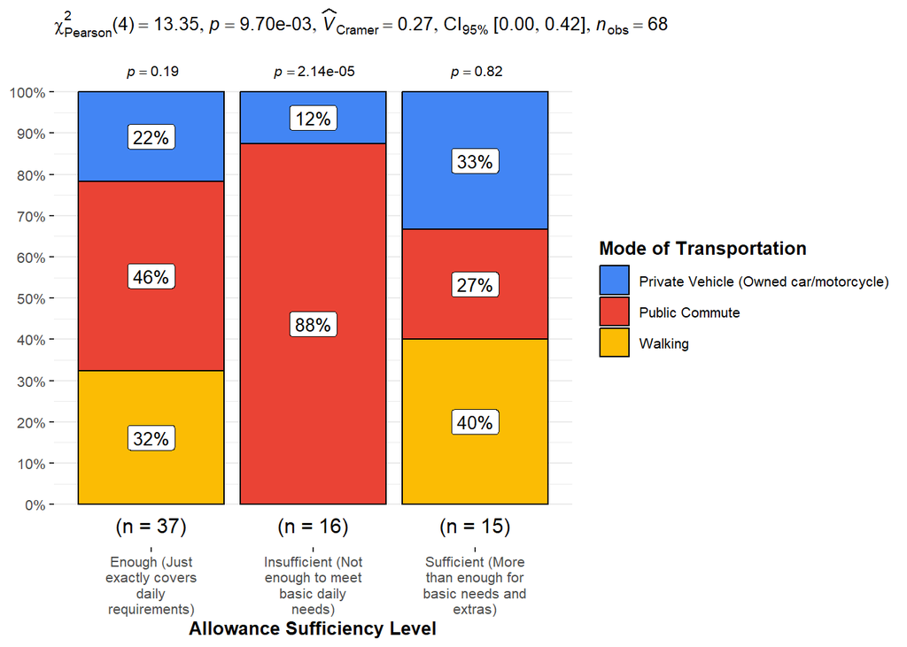

```r
ggbarstats(
  data = df,
  x = Mode,
  y = sufficiency,
  bf.message = FALSE,
  xlab = "Allowance Sufficiency Level",
  legend.title = "Mode of Transportation"
) +
  ggplot2::scale_x_discrete(labels = scales::label_wrap(18))
```

Based on the bar chart in Figure 1 and the $p-value$ being less than $5\%$ ($\chi^2(4) = 13.35$, $p-value = 0.0097$, Cramér’s $V = 0.27$), we reject the null hypothesis. There is significant evidence that a student’s mode of transportation is associated with their allowance sufficiency level. Specifically, as shown in Figure 1, students who reported having insufficient allowance predominantly relied on public commute ($88\%$), whereas those with sufficient allowance were more evenly distributed across walking ($40\%$), private vehicles ($33\%$), and public commute ($27\%$).